# Week 5 Live Session

Data Science Ethics

Dr Zak Varty

## Session Plan

1. Assessment questions speed-run
2. Week in review
3. Professional Guidelines
4. What would you do?
5. Data anonymisation walk through (if time allows)

# Questions Speed-run

## From the inbox:

### Do I need to test my code?

I can’t make you do it, but if I were sharing my work with someone then I’d like to know it works as I intended.

### Thoughts on Scripting + LaTeX vs Quarto vs Rmd vs JuPyteR

See section 2.3 of the notes. Good points about user familiarity, in any case povide enough information for someone new to that ecosystem.

## File Size Limits

Large datasets should not be stored within a project directory. (And might cause issues with uploading your zip file)

Instead:

- use a data version control service,
- host the data online and download only the parts of it that are needed within your scripts,
- link in the documentation to where the full data may be downloaded (giving appropriate warning of the large file size)

## Other Questions?

Anything that I missed or you forgot to ask?

# Week in Review

## Week In Review

**Privacy**

- Human and legal right (GDPR)
- $k$-anonymity
- Netflix De-anonymisation

**Fairness**

- Most at risk: minorities & historically disadvantaged groups
- Fairness metrics & loss function
- Gender Shades case study

**Codes of Conduct**

- Tools for supporting good work
- *Highly* variable in detail
- Explore more in this session.

## Professional Ethics

Lots of ways of partitioning the same ideas

- [Floridi and Cowls](https://hdsr.mitpress.mit.edu/pub/l0jsh9d1/release/8) - 5 Principles of Ethical AI
  - Beneficence,
  - Non-maleficence,
  - Autonomy,
  - Justice,
  - Explicability
- [Alan Turing Institute](https://www.turing.ac.uk/sites/default/files/2019-06/understanding_artificial_intelligence_ethics_and_safety.pdf) - FAST
  - Fairness
  - Accountability
  - Sustainability
  - Safety
  - Transparency

## Focus 5 Principles

## Ethical Frameworks - 5 Principles

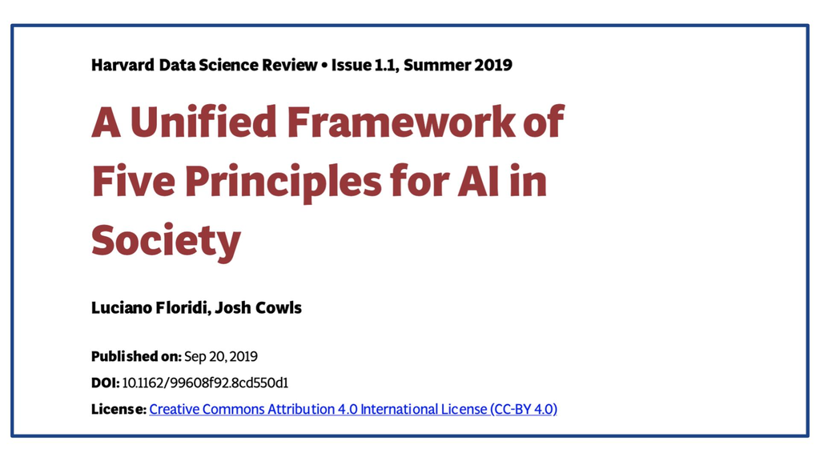

## Ethical Frameworks - Organisational Ethics

[figure not shown]

## Activity - Organisational Ethics

Questions you might try to answer:

- Who is the intended audience for your document?
- How do the published guidelines link to the guidelines of Floridi and Cowls?
- How effectively does the document achieve its goal?
- What would you change or do differently?

`20:00`

## Document Links

- Group 1 [The European Union](https://op.europa.eu/s/sUPP)
- Group 2 [The Royal Statistical Society](https://rss.org.uk/RSS/media/News-and-publications/Publications/Reports%20and%20guides/A-Guide-for-Ethical-Data-Science-Final-Oct-2019.pdf)
- Group 3 [The Dutch Government](https://www.government.nl/documents/reports/2021/07/31/impact-assessment-fundamental-rights-and-algorithms)
- Group 4 [The UK Government](https://www.gov.uk/guidance/understanding-artificial-intelligence-ethics-and-safety)
- Group 5 (Online) [Google](https://ai.google/responsibility/principles/)

# Feedback from Groups (20 mins)

## Group 1

**The European Union**

Questions you might try to answer:

- Who is the intended audience for your document?
- How do the published guidelines link to the guidelines of Floridi and Cowls?
- How effectively does the document achieve its goal?
- What would you change or do differently?

`04:00`

## Group 2

**The Royal Statistical Society**

Questions you might try to answer:

- Who is the intended audience for your document?
- How do the published guidelines link to the guidelines of Floridi and Cowls?
- How effectively does the document achieve its goal?
- What would you change or do differently?

`04:00`

## Group 3

**The Dutch Government**

Questions you might try to answer:

- Who is the intended audience for your document?
- How do the published guidelines link to the guidelines of Floridi and Cowls?
- How effectively does the document achieve its goal?
- What would you change or do differently?

`04:00`

## Group 4

**The UK Government**

Questions you might try to answer:

- Who is the intended audience for your document?
- How do the published guidelines link to the guidelines of Floridi and Cowls?
- How effectively does the document achieve its goal?
- What would you change or do differently?

`04:00`

## Group 5

**Google**

Questions you might try to answer:

- Who is the intended audience for your document?
- How do the published guidelines link to the guidelines of Floridi and Cowls?
- How effectively does the document achieve its goal?
- What would you change or do differently?

`04:00`

# Making Information Palatable (5 mins)

## Form as well as function?

In the final few minutes, discuss the documents themselves (rather than their content).

How might the delivery of information impact on how it is recieved / acted upon?

- How important is length?
- How important is presentation?
- Does your organisation have a similar document?
- How does it compare?

# BREAK

`10:00`

# Discussion Points / Case Studies / Thought Experiments

## Predicting Pregnancy

- What predictors / target variables do you feel should not be used in predictive models for targeted advertising?

`07:00`

## Doorbell

Doorbell cameras are thing now. What if they offered personalised ringtones, depending who was at the door?

- What issues might this present in terms of privacy and fairness?
- Which companies would you feel comfortable having this type of information about you? (And may already)
- How could this data be misused by the company or if leaked?

`10:00`

## Journo

Suppose you used web scraping to collect public data of 100,000 social media users for you dissertation.

A journalist asks for access to the data, promising not to make the content public.

- Would you provide your data and / or code?
- Would your answer change if it were a sociology lecturer writing a paper on digital communities?

`07:00`

# Optional: K-anonymisation walk-through

# Thank you for your time, attention and enthusiasm!

Any final feedback would be much appreciated

`menti.com`: `2546 5388`

[figure not shown]

Effective Data Science: Ethics - Live Session - Zak Varty